# Case Study 6.1 - NYC Taxi Trips

# Note: If you close this notebook at any time, you will have to run all cells again upon re-opening it.

# BEGINNER PYTHON

As this is a beginner version, we include a lot of code here to help you along the way.

# Identification Information

```python
# YOUR NAME              = JIAHAN LI
# YOUR MITX PRO USERNAME = JAYHON626
# YOUR MITX PRO E-MAIL   = JAYHON626@GMAIL.COM
```

# Setup

Run these cells to install all the packages you need to complete the remainder of the case study. This may take a few minutes, so please be patient.

```python
!pip install featuretools==0.1.19
```

```
twisted 18.7.0 requires PyHamcrest>=1.9.0, which is not installed.
You are using pip version 10.0.1, however version 18.1 is available.
```

# Import

Import the required tools into the notebook.

```python
import featuretools as ft
import matplotlib
import matplotlib.pyplot as plt
import numpy as np
import utils
from featuretools.primitives import (Count, Day, Hour, Max, Mean, Median, Min,
                                     Minute, Month, Std, Sum, Week, Weekday,
                                     Weekend)
from sklearn.ensemble import GradientBoostingRegressor
from utils import (compute_features, feature_importances, load_nyc_taxi_data,
                   preview)

print('Import successful!')
```

```
Import successful!
```

```python
%matplotlib inline
```

```python
assert ft.__version__ == '0.1.19', 'Make sure you run the command above with the correct version.'
```

# Data

Load the NYC taxi trip data. Note that this may take a minute or two, so please be patient.

```python
trips, pickup_neighborhoods, dropoff_neighborhoods = load_nyc_taxi_data()
preview(trips, 10)
print('Data load successful!')
```

```
Data load successful!
```

We can also plot some aspects of the data to get a better sense of its distributions. For instance, here is the `trip_duration` variable we are going to try to predict.

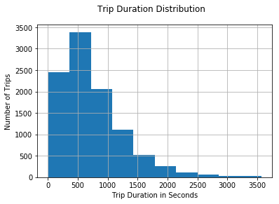

```
Histogram generation successful!
```

```python
trips.trip_duration.hist()
plt.xlabel('Trip Duration in Seconds')
plt.ylabel('Number of Trips')
plt.suptitle('Trip Duration Distribution')
plt.show()
print('Histogram generation successful!')
```

```python
trips.shape[0]  # Tells us how many trips are in the dataset
```

```
10000
```

# QUESTION 1: DATA ANALYSIS

**Describe the dataset. How many trips are in the dataset? How would you describe the distribution of trip durations? Is there anything else we should observe? Make sure the histogram is visible in the notebook.**

1. there are totla of 10000 trips
2. the duration is a skewed normal-ish distribution. With duration of the rides dominantly centralizing within the range of 0-1000 sec

# Entities and Relationships

```python
entities = {
    "trips": (trips, "id", 'pickup_datetime'),
    "pickup_neighborhoods": (pickup_neighborhoods, "neighborhood_id"),
    "dropoff_neighborhoods": (dropoff_neighborhoods, "neighborhood_id"),
}

relationships = [("pickup_neighborhoods", "neighborhood_id", "trips", "pickup_neighborhood"),
                 ("dropoff_neighborhoods", "neighborhood_id", "trips", "dropoff_neighborhood")]

print('Entities and relationships successful!')
```

```
Entities and relationships successful!
```

# Transform Primitives

```python
trans_primitives = [Weekend]

# This may take some time to compute
features = ft.dfs(entities=entities,
                  relationships=relationships,
                  target_entity="trips",
                  trans_primitives=trans_primitives,
                  agg_primitives=[],
                  ignore_variables={"trips": ["pickup_latitude", "pickup_longitude",
                                              "dropoff_latitude", "dropoff_longitude"]},
                  features_only=True)

print('Transform primitives successful!')
```

```
Transform primitives successful!
```

Here are the features that we just created. Note: This list may contain the `trip_duration` variable. But, rest assured that we will not actually use this variable in training. Our code removes that variable in `utils.py`.

```python
print(f"Number of features: {len(features)}")
features
```

```
Number of features: 13
```

```
[<Feature: vendor_id>,
 <Feature: passenger_count>,
 <Feature: trip_distance>,
 <Feature: payment_type>,
 <Feature: trip_duration>,
 <Feature: pickup_neighborhood>,
 <Feature: dropoff_neighborhood>,
 <Feature: IS_WEEKEND(pickup_datetime)>,
 <Feature: IS_WEEKEND(dropoff_datetime)>,
 <Feature: pickup_neighborhoods.latitude>,
 <Feature: pickup_neighborhoods.longitude>,
 <Feature: dropoff_neighborhoods.latitude>,
 <Feature: dropoff_neighborhoods.longitude>]
```

Finally, we compute the feature matrix from these features.

```python
feature_matrix = compute_features(features, trips[['id', 'pickup_datetime']])
preview(feature_matrix, 5)
```

```
Elapsed: 00:00 | Remaining: 00:00 | Progress: 100%|██████████|| Calculated: 1/1 cutoff times
Finishing computing...
```

| id | trip_distance | trip_duration | IS_WEEKEND(dropoff_datetime) | dropoff_neighborhood = D | dropoff_neighborhood = AA | dropoff_neighborhood = H | dropoff_neighborhood = P | dropoff_neighborhood = AR | dropoff_neighborhood = AD | dropoff_neighborhood = A | ... | pickup_neighborhood = AO | pickup_neighborhood = AD | pickup_neighborhood = Q | pickup_neighborhood = AR | pickup_neighborhood = AP | pickup_neighborhood = H | pickup_neighborhoods.latitude | IS_WEEKEND(pickup_datetime) | dropoff_neighborhoods.latitude | vendor_id |
| --- | --- | --- | --- | --- | --- | --- | --- | --- | --- | --- | --- | --- | --- | --- | --- | --- | --- | --- | --- | --- | --- |
| 514030 | 2.46 | 1039 | True | 0 | 0 | 0 | 0 | 0 | 0 | 0 | ... | 0 | 0 | 0 | 0 | 0 | 0 | 40.757707 | True | 40.766809 | 2 |
| 514031 | 7.90 | 1454 | True | 0 | 0 | 0 | 0 | 0 | 0 | 0 | ... | 0 | 0 | 0 | 0 | 0 | 0 | 40.744928 | True | 40.793597 | 1 |
| 514032 | 1.00 | 1168 | True | 0 | 0 | 0 | 0 | 0 | 0 | 0 | ... | 0 | 0 | 0 | 0 | 0 | 1 | 40.729652 | True | 40.740333 | 1 |
| 514033 | 0.02 | 35 | True | 0 | 0 | 0 | 0 | 0 | 0 | 0 | ... | 0 | 0 | 0 | 0 | 0 | 0 | 40.720245 | True | 40.720245 | 2 |
| 514034 | 19.00 | 3470 | True | 0 | 0 | 0 | 0 | 0 | 0 | 0 | ... | 0 | 0 | 0 | 0 | 0 | 0 | 40.646194 | True | 40.785005 | 1 |

5 rows × 31 columns

# First Model

```python
# Split data
X_train, y_train, X_test, y_test = utils.get_train_test_fm(feature_matrix,.75)
y_train = np.log(y_train + 1)
y_test = np.log(y_test + 1)

print('Data split successful!')
```

```
Data split successful!
```

```python
# This should train within a minute or so
model = GradientBoostingRegressor(verbose=True)
model.fit(X_train, y_train)
print(model.score(X_test, y_test)) # This is the R^2 value of the prediction

print('Training successful!')
```

```
      Iter       Train Loss   Remaining Time
         1           0.4736            1.57s
         2           0.4148            1.14s
         3           0.3661            1.01s
         4           0.3266            0.93s
         5           0.2934            0.86s
         6           0.2665            0.84s
         7           0.2441            0.81s
         8           0.2257            0.78s
         9           0.2103            0.77s
        10           0.1973            0.75s
        20           0.1434            0.60s
        30           0.1312            0.50s
        40           0.1248            0.39s
        50           0.1218            0.30s
        60           0.1191            0.23s
        70           0.1174            0.17s
        80           0.1158            0.11s
        90           0.1147            0.05s
       100           0.1137            0.00s
0.7527788676087426
Training successful!
```

# QUESTION 2: FIRST MODEL

**Describe the 2 new features that we added to the model. Do you think these improved the performance from a model that did not have these features? Why?**

1. Definitely because on the weekend traffic conditions are very different from week days. For example: streets are busier espcailly during usual work hours.

# More Transform Primitives

```python
trans_primitives = [Minute, Hour, Day, Week, Month, Weekday, Weekend]

features = ft.dfs(entities=entities,
                  relationships=relationships,
                  target_entity="trips",
                  trans_primitives=trans_primitives,
                  agg_primitives=[],
                  ignore_variables={"trips": ["pickup_latitude", "pickup_longitude",
                                              "dropoff_latitude", "dropoff_longitude"]},
                  features_only=True)

print('Transform primitives successful!')
```

```
Transform primitives successful!
```

```python
print(f"Number of features: {len(features)}")
features
```

```
Number of features: 25
```

```
[<Feature: vendor_id>,
 <Feature: passenger_count>,
 <Feature: trip_distance>,
 <Feature: payment_type>,
 <Feature: trip_duration>,
 <Feature: pickup_neighborhood>,
 <Feature: dropoff_neighborhood>,
 <Feature: MINUTE(pickup_datetime)>,
 <Feature: MINUTE(dropoff_datetime)>,
 <Feature: HOUR(pickup_datetime)>,
 <Feature: HOUR(dropoff_datetime)>,
 <Feature: DAY(pickup_datetime)>,
 <Feature: DAY(dropoff_datetime)>,
 <Feature: WEEK(pickup_datetime)>,
 <Feature: WEEK(dropoff_datetime)>,
 <Feature: MONTH(pickup_datetime)>,
 <Feature: MONTH(dropoff_datetime)>,
 <Feature: WEEKDAY(pickup_datetime)>,
 <Feature: WEEKDAY(dropoff_datetime)>,
 <Feature: IS_WEEKEND(pickup_datetime)>,
 <Feature: IS_WEEKEND(dropoff_datetime)>,
 <Feature: pickup_neighborhoods.latitude>,
 <Feature: pickup_neighborhoods.longitude>,
 <Feature: dropoff_neighborhoods.latitude>,
 <Feature: dropoff_neighborhoods.longitude>]
```

```python
feature_matrix = compute_features(features, trips[['id', 'pickup_datetime']])
preview(feature_matrix, 5)
```

```
Elapsed: 00:00 | Remaining: 00:00 | Progress: 100%|██████████|| Calculated: 1/1 cutoff times
Finishing computing...
```

| id | IS_WEEKEND(dropoff_datetime) | dropoff_neighborhood = D | dropoff_neighborhood = AA | dropoff_neighborhood = H | dropoff_neighborhood = P | dropoff_neighborhood = AR | dropoff_neighborhood = AD | dropoff_neighborhood = A | dropoff_neighborhood = AB | dropoff_neighborhood = AV | ... | WEEK(pickup_datetime) | trip_distance | MINUTE(pickup_datetime) | HOUR(pickup_datetime) | pickup_neighborhoods.latitude | payment_type | WEEKDAY(dropoff_datetime) | passenger_count | WEEKDAY(pickup_datetime) | DAY(pickup_datetime) |
| --- | --- | --- | --- | --- | --- | --- | --- | --- | --- | --- | --- | --- | --- | --- | --- | --- | --- | --- | --- | --- | --- |
| 514030 | True | 0 | 0 | 0 | 0 | 0 | 0 | 0 | 0 | 0 | ... | 13 | 2.46 | 0 | 0 | 40.757707 | 1 | 5 | 1 | 5 | 2 |
| 514031 | True | 0 | 0 | 0 | 0 | 0 | 0 | 0 | 0 | 0 | ... | 13 | 7.90 | 0 | 0 | 40.744928 | 1 | 5 | 2 | 5 | 2 |
| 514032 | True | 0 | 0 | 0 | 0 | 0 | 0 | 0 | 0 | 0 | ... | 13 | 1.00 | 0 | 0 | 40.729652 | 1 | 5 | 1 | 5 | 2 |
| 514033 | True | 0 | 0 | 0 | 0 | 0 | 0 | 0 | 0 | 0 | ... | 13 | 0.02 | 0 | 0 | 40.720245 | 2 | 5 | 1 | 5 | 2 |
| 514034 | True | 0 | 0 | 0 | 0 | 0 | 0 | 0 | 0 | 0 | ... | 13 | 19.00 | 1 | 0 | 40.646194 | 1 | 5 | 2 | 5 | 2 |

5 rows × 43 columns

```python
# Re-split data
X_train, y_train, X_test, y_test = utils.get_train_test_fm(feature_matrix,.75)
y_train = np.log(y_train + 1)
y_test = np.log(y_test + 1)

print('Data split successful!')
```

```
Data split successful!
```

```python
# This should train within a minute or so
model = GradientBoostingRegressor(verbose=True)
model.fit(X_train, y_train)
print(model.score(X_test, y_test)) # This is the R^2 value of the prediction

print('Training successful!')
```

```
      Iter       Train Loss   Remaining Time
         1           0.4736            1.01s
         2           0.4148            0.93s
         3           0.3661            0.93s
         4           0.3264            0.95s
         5           0.2930            0.91s
         6           0.2660            0.90s
         7           0.2432            0.88s
         8           0.2245            0.88s
         9           0.2090            0.86s
        10           0.1960            0.85s
        20           0.1362            0.72s
        30           0.1200            0.61s
        40           0.1126            0.50s
        50           0.1079            0.39s
        60           0.1047            0.30s
        70           0.1016            0.21s
        80           0.0986            0.14s
        90           0.0938            0.07s
       100           0.0899            0.00s
0.8059573190397493
Training successful!
```

# QUESTION 3: SECOND MODEL

**Describe the rest of the new features that we just added to the model. How did this affect performance? Did we have to sacrifice training time?**

1. It enhanced performance. R^2 score went from 0.75 to 0.8.
2. Comparatively no. Whether we spent more or less time on the se ond model, it's alsmot neglegible.

# Aggregation Primitives

```python
trans_primitives = [Minute, Hour, Day, Week, Month, Weekday, Weekend]
aggregation_primitives = [Count, Sum, Mean, Median, Std, Max, Min]

features = ft.dfs(entities=entities,
                  relationships=relationships,
                  target_entity="trips",
                  trans_primitives=trans_primitives,
                  agg_primitives=aggregation_primitives,
                  ignore_variables={"trips": ["pickup_latitude", "pickup_longitude",
                                              "dropoff_latitude", "dropoff_longitude"]},
                  features_only=True)

print('Aggregation primitives successful!')
```

```
Aggregation primitives successful!
```

```python
print(f"Number of features: {len(features)}")
features
```

```
Number of features: 75
```

```
[<Feature: vendor_id>,
 <Feature: passenger_count>,
 <Feature: trip_distance>,
 <Feature: payment_type>,
 <Feature: trip_duration>,
 <Feature: pickup_neighborhood>,
 <Feature: dropoff_neighborhood>,
 <Feature: MINUTE(pickup_datetime)>,
 <Feature: MINUTE(dropoff_datetime)>,
 <Feature: HOUR(pickup_datetime)>,
 <Feature: HOUR(dropoff_datetime)>,
 <Feature: DAY(pickup_datetime)>,
 <Feature: DAY(dropoff_datetime)>,
 <Feature: WEEK(pickup_datetime)>,
 <Feature: WEEK(dropoff_datetime)>,
 <Feature: MONTH(pickup_datetime)>,
 <Feature: MONTH(dropoff_datetime)>,
 <Feature: WEEKDAY(pickup_datetime)>,
 <Feature: WEEKDAY(dropoff_datetime)>,
 <Feature: IS_WEEKEND(pickup_datetime)>,
 <Feature: IS_WEEKEND(dropoff_datetime)>,
 <Feature: pickup_neighborhoods.latitude>,
 <Feature: pickup_neighborhoods.longitude>,
 <Feature: dropoff_neighborhoods.latitude>,
 <Feature: dropoff_neighborhoods.longitude>,
 <Feature: pickup_neighborhoods.COUNT(trips)>,
 <Feature: pickup_neighborhoods.SUM(trips.vendor_id)>,
 <Feature: pickup_neighborhoods.SUM(trips.passenger_count)>,
 <Feature: pickup_neighborhoods.SUM(trips.trip_distance)>,
 <Feature: pickup_neighborhoods.SUM(trips.trip_duration)>,
 <Feature: pickup_neighborhoods.MEAN(trips.vendor_id)>,
 <Feature: pickup_neighborhoods.MEAN(trips.passenger_count)>,
 <Feature: pickup_neighborhoods.MEAN(trips.trip_distance)>,
 <Feature: pickup_neighborhoods.MEAN(trips.trip_duration)>,
 <Feature: pickup_neighborhoods.MEDIAN(trips.vendor_id)>,
 <Feature: pickup_neighborhoods.MEDIAN(trips.passenger_count)>,
 <Feature: pickup_neighborhoods.MEDIAN(trips.trip_distance)>,
 <Feature: pickup_neighborhoods.MEDIAN(trips.trip_duration)>,
 <Feature: pickup_neighborhoods.STD(trips.vendor_id)>,
 <Feature: pickup_neighborhoods.STD(trips.passenger_count)>,
```

[output cut: 20 more lines]

```
 <Feature: dropoff_neighborhoods.MEDIAN(trips.passenger_count)>,
 <Feature: dropoff_neighborhoods.MEDIAN(trips.trip_distance)>,
 <Feature: dropoff_neighborhoods.MEDIAN(trips.trip_duration)>,
 <Feature: dropoff_neighborhoods.STD(trips.vendor_id)>,
 <Feature: dropoff_neighborhoods.STD(trips.passenger_count)>,
 <Feature: dropoff_neighborhoods.STD(trips.trip_distance)>,
 <Feature: dropoff_neighborhoods.STD(trips.trip_duration)>,
 <Feature: dropoff_neighborhoods.MAX(trips.vendor_id)>,
 <Feature: dropoff_neighborhoods.MAX(trips.passenger_count)>,
 <Feature: dropoff_neighborhoods.MAX(trips.trip_distance)>,
 <Feature: dropoff_neighborhoods.MAX(trips.trip_duration)>,
 <Feature: dropoff_neighborhoods.MIN(trips.vendor_id)>,
 <Feature: dropoff_neighborhoods.MIN(trips.passenger_count)>,
 <Feature: dropoff_neighborhoods.MIN(trips.trip_distance)>,
 <Feature: dropoff_neighborhoods.MIN(trips.trip_duration)>]
```

```python
# This may take a bit longer to compute, so please be patient
feature_matrix = compute_features(features, trips[['id', 'pickup_datetime']])
preview(feature_matrix, 5)
```

```
Elapsed: 00:00 | Remaining: ? | Progress:   0%|          || Calculated: 0/1 cutoff times
```

```
Elapsed: 00:00 | Remaining: 00:00 | Progress: 100%|██████████|| Calculated: 1/1 cutoff times
Finishing computing...
```

| id | IS_WEEKEND(dropoff_datetime) | pickup_neighborhoods.MEDIAN(trips.trip_duration) | pickup_neighborhoods.STD(trips.trip_distance) | MONTH(pickup_datetime) | dropoff_neighborhoods.STD(trips.trip_duration) | WEEK(dropoff_datetime) | pickup_neighborhoods.longitude | pickup_neighborhoods.MIN(trips.passenger_count) | HOUR(pickup_datetime) | payment_type | ... | pickup_neighborhood = AO | pickup_neighborhood = AD | pickup_neighborhood = Q | pickup_neighborhood = AR | pickup_neighborhood = AP | pickup_neighborhood = H | vendor_id | pickup_neighborhoods.SUM(trips.vendor_id) | DAY(dropoff_datetime) | dropoff_neighborhoods.MAX(trips.trip_duration) |
| --- | --- | --- | --- | --- | --- | --- | --- | --- | --- | --- | --- | --- | --- | --- | --- | --- | --- | --- | --- | --- | --- |
| 514030 | True | NaN | NaN | 4 | NaN | 13 | -73.986446 | NaN | 0 | 1 | ... | 0 | 0 | 0 | 0 | 0 | 0 | 2 | NaN | 2 | NaN |
| 514031 | True | NaN | NaN | 4 | NaN | 13 | -73.919159 | NaN | 0 | 1 | ... | 0 | 0 | 0 | 0 | 0 | 0 | 1 | NaN | 2 | NaN |
| 514032 | True | NaN | NaN | 4 | NaN | 13 | -73.991595 | NaN | 0 | 1 | ... | 0 | 0 | 0 | 0 | 0 | 1 | 1 | NaN | 2 | NaN |
| 514033 | True | NaN | NaN | 4 | NaN | 13 | -73.987205 | NaN | 0 | 2 | ... | 0 | 0 | 0 | 0 | 0 | 0 | 2 | NaN | 2 | NaN |
| 514034 | True | NaN | NaN | 4 | NaN | 13 | -73.785073 | NaN | 0 | 1 | ... | 0 | 0 | 0 | 0 | 0 | 0 | 1 | NaN | 2 | NaN |

5 rows × 93 columns

```python
# Re-split data
X_train, y_train, X_test, y_test = utils.get_train_test_fm(feature_matrix,.75)
y_train = np.log(y_train + 1)
y_test = np.log(y_test + 1)

print('Data split successful!')
```

```
Data split successful!
```

```python
# This should train within a minute or so
model = GradientBoostingRegressor(verbose=True)
model.fit(X_train, y_train)
print(model.score(X_test, y_test)) # This is the R^2 value of the prediction

print('Training successful!')
```

```
      Iter       Train Loss   Remaining Time
         1           0.4736            0.98s
         2           0.4148            0.91s
         3           0.3661            0.90s
         4           0.3264            0.89s
         5           0.2930            0.88s
         6           0.2660            0.87s
         7           0.2432            0.85s
         8           0.2245            0.84s
         9           0.2090            0.83s
        10           0.1960            0.82s
        20           0.1362            0.71s
        30           0.1200            0.60s
        40           0.1126            0.48s
        50           0.1079            0.38s
        60           0.1047            0.29s
        70           0.1016            0.21s
        80           0.0986            0.13s
        90           0.0938            0.07s
       100           0.0899            0.00s
0.8060128240391375
Training successful!
```

# Evaluate on Test Data

```python
y_pred = model.predict(X_test)
y_pred = np.exp(y_pred) - 1 # undo the log we took earlier

print('y_pred computation successful!')
```

```
y_pred computation successful!
```

```python
# Print the first 5 predictions
y_pred[:5]
```

```
array([453.4415368 , 666.8066337 , 634.00494622, 617.34019506,
       407.96332751])
```

```
Histogram generation successful!
```

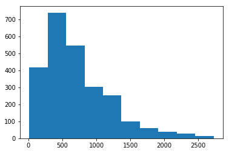

```python
# Create a histogram of all of them
matplotlib.pyplot.hist(y_pred)

print('Histogram generation successful!')
```

# QUESTION 4: MODEL PREDICTIONS

**Analyze the model predictions. Does the output distribution match the one you made earlier in the case study? What other features/strategies could we use to make our model even better, if we had more time?**

1. It does mostly.
2. The features already provided by algorithms are already pretty extensive. But i would try adding SECOND in trans_primitives. It should take more time to compute but results would be more precise.

# Feature Importance

```python
feature_importances(model, feature_matrix.columns, n=25)
```

```
1: Feature: pickup_neighborhoods.MAX(trips.passenger_count), 0.325
2: Feature: dropoff_neighborhoods.STD(trips.trip_duration), 0.107
3: Feature: HOUR(pickup_datetime), 0.105
4: Feature: MINUTE(dropoff_datetime), 0.085
5: Feature: dropoff_neighborhoods.MEAN(trips.passenger_count), 0.070
6: Feature: pickup_neighborhoods.longitude, 0.069
7: Feature: MONTH(pickup_datetime), 0.062
8: Feature: payment_type, 0.060
9: Feature: dropoff_neighborhoods.MEDIAN(trips.vendor_id), 0.029
10: Feature: WEEK(dropoff_datetime), 0.012
11: Feature: pickup_neighborhoods.SUM(trips.trip_distance), 0.012
12: Feature: IS_WEEKEND(pickup_datetime), 0.009
13: Feature: pickup_neighborhoods.MIN(trips.trip_distance), 0.009
14: Feature: dropoff_neighborhoods.STD(trips.passenger_count), 0.007
15: Feature: dropoff_neighborhoods.MEAN(trips.trip_distance), 0.006
16: Feature: dropoff_neighborhoods.MEDIAN(trips.trip_distance), 0.005
17: Feature: dropoff_neighborhood = AA, 0.004
18: Feature: dropoff_neighborhoods.MAX(trips.vendor_id), 0.003
19: Feature: dropoff_neighborhoods.MEDIAN(trips.trip_duration), 0.003
20: Feature: pickup_neighborhoods.SUM(trips.passenger_count), 0.003
21: Feature: dropoff_neighborhoods.MEAN(trips.trip_duration), 0.002
22: Feature: pickup_neighborhoods.latitude, 0.002
23: Feature: dropoff_neighborhood = H, 0.002
24: Feature: pickup_neighborhoods.MAX(trips.trip_duration), 0.002
25: Feature: dropoff_neighborhoods.COUNT(trips), 0.002
```

# QUESTION 5: FEATURE IMPORTANCE

**Analyze the feature importance values you just computed above. Do they make sense? Are there any values you are surprised by? Give some brief explanations as to why these features are relevant in computing the `trip_duration` target variable.**

1. A lot of them make sense.
2. max passenger count per trip in very neighbourhood makes sense to be important because more passengers the trip has, the longer its duration is likely to be. However I was expecting MEAN to be more important than MAX.
3. Payment type doesn't matter that much because logically it has nothing(negligible) do to with trip duration.
4. Surprisingly the hour(pickup_datetime) and minute(dropoff_datetime) matter the most in the timing catogory. It seems to me to be not so logical and random.

Great job! Now, make sure you check out the **Conclusion** section of the [instruction manual](https://courses.edx.org/asset-v1:MITxPRO+DSx+2T2018+type@asset+block@6.1_instruction_manual.html) to wrap up this case study properly.